# DMHR Assignment

### Prescriptions for cardiovascular and antidepressant drugs

The first two characters of the BNF code are the chapter (chapter 2 = ^02) and the next two the section (chapter 4 section 3 = ^0403).

This can be accomplished using regex or pandasql. Code for both is presented and sql used as the package was listed as approved but better performance was obtained with regex.

#### Cardiovascular

```python
cvd_sql = """SELECT * FROM scrips_raw WHERE BNFCODE LIKE '02%'"""
scrips_cvd = pysqldf(cvd_sql)

# Select using regex (had better performance)
# scrips_cvd = scrips_raw[scrips_raw.BNFCODE.str.contains("^02", regex=True)]
```

```python
print('There were ', np.sum(scrips_cvd.ITEMS), ' items prescribed by primary care establishments (including non-GP practices) for ',
      'cardiovascular drugs (defined as those in chapter 02 of the BNF). A total of ', scrips_cvd.CODE.nunique(), ' providers prescribed ',
      scrips_cvd.BNFCODE.nunique(), ' different drugs during April 2018 in England. The total cost of cvd prescriptions was £',
      round(np.sum(scrips_cvd.TOTALCOST),2),
      sep = '')
```

[output not shown]

```python
# group prescribing data by BNF
scrips_cvd_bnf_grouped = scrips_cvd.groupby(['BNFCODE', 'BNFNAME']).sum()
```

```python
print('The 10 most prescribed drugs were:')
scrips_cvd_bnf_grouped.sort_values('ITEMS', axis=0, ascending=False, kind='quicksort', na_position='last').head(10)
```

```
The 10 most prescribed drugs were:
```

| BNFCODE | BNFNAME | ITEMS | NIC | ACTCOST | QUANTITY | PERIOD | TOTALCOST |
| --- | --- | --- | --- | --- | --- | --- | --- |
| 0206020A0AAAAAA | Amlodipine_Tab 5mg | 1439739 | 2541471.95 | 2392086.43 | 49595851 | 1529674320 | 7.099423e+08 |
| 0212000B0AAABAB | Atorvastatin_Tab 20mg | 1431023 | 1280629.42 | 1223368.38 | 48157431 | 1494560424 | 3.763402e+08 |
| 0209000A0AAABAB | Aspirin Disper_Tab 75mg | 1415301 | 515494.96 | 521502.98 | 43752171 | 1491129756 | 1.610610e+08 |
| 0212000Y0AAADAD | Simvastatin_Tab 40mg | 1100977 | 839258.34 | 808711.85 | 35932841 | 1475389044 | 1.999831e+08 |
| 0212000B0AAACAC | Atorvastatin_Tab 40mg | 965700 | 1077775.46 | 1031034.31 | 30078354 | 1488909912 | 2.136427e+08 |
| 0206020A0AAABAB | Amlodipine_Tab 10mg | 926675 | 1796639.47 | 1690146.43 | 31711013 | 1495973052 | 3.228051e+08 |
| 0205051R0AAADAD | Ramipril_Cap 10mg | 832680 | 988669.23 | 935280.30 | 29419334 | 1480232340 | 1.987285e+08 |
| 0202010B0AAABAB | Bendroflumethiazide_Tab 2.5mg | 813364 | 292085.70 | 288587.92 | 29181592 | 1475590848 | 5.371579e+07 |
| 0209000C0AAAAAA | Clopidogrel_Tab 75mg | 784229 | 1014555.17 | 973762.42 | 21544252 | 1488102696 | 1.655327e+08 |
| 0212000Y0AAABAB | Simvastatin_Tab 20mg | 763827 | 404395.65 | 396569.62 | 24991556 | 1471554768 | 6.819103e+07 |

```python
print('While the 10 drugs where the most money was spent were:')
scrips_cvd_bnf_grouped.sort_values('TOTALCOST', axis=0, ascending=False, kind='quicksort', na_position='last').head(10)
```

```
While the 10 drugs where the most money was spent were:
```

| BNFCODE | BNFNAME | ITEMS | NIC | ACTCOST | QUANTITY | PERIOD | TOTALCOST |
| --- | --- | --- | --- | --- | --- | --- | --- |
| 0206020A0AAAAAA | Amlodipine_Tab 5mg | 1439739 | 2541471.95 | 2392086.43 | 49595851 | 1529674320 | 7.099423e+08 |
| 0208020Y0AAACAC | Rivaroxaban_Tab 20mg | 228645 | 11954784.60 | 11094375.29 | 6641547 | 1455814056 | 6.652725e+08 |
| 0208020Z0AAABAB | Apixaban_Tab 5mg | 219971 | 11389346.70 | 10569680.46 | 11988786 | 1457630292 | 6.334110e+08 |
| 0212000B0AAABAB | Atorvastatin_Tab 20mg | 1431023 | 1280629.42 | 1223368.38 | 48157431 | 1494560424 | 3.763402e+08 |
| 0206020A0AAABAB | Amlodipine_Tab 10mg | 926675 | 1796639.47 | 1690146.43 | 31711013 | 1495973052 | 3.228051e+08 |
| 0212000B0AAACAC | Atorvastatin_Tab 40mg | 965700 | 1077775.46 | 1031034.31 | 30078354 | 1488909912 | 2.136427e+08 |
| 0212000Y0AAADAD | Simvastatin_Tab 40mg | 1100977 | 839258.34 | 808711.85 | 35932841 | 1475389044 | 1.999831e+08 |
| 0205051R0AAADAD | Ramipril_Cap 10mg | 832680 | 988669.23 | 935280.30 | 29419334 | 1480232340 | 1.987285e+08 |
| 0208020Z0AAAAAA | Apixaban_Tab 2.5mg | 127975 | 5554284.25 | 5161392.03 | 5846615 | 1402941408 | 1.773789e+08 |
| 0209000C0AAAAAA | Clopidogrel_Tab 75mg | 784229 | 1014555.17 | 973762.42 | 21544252 | 1488102696 | 1.655327e+08 |

#### Antidepressant

```python
dep_sql = """SELECT * FROM scrips_raw WHERE BNFCODE LIKE '0403%'"""
scrips_dep = pysqldf(dep_sql)

# Select using regex (had better performance)
# scrips_dep = scrips_raw[scrips_raw.BNFCODE.str.contains("^0403", regex=True)]
```

```python
print('There were ', np.sum(scrips_dep.ITEMS), ' items prescribed by primary care establishments (including non-GP practices) for ',
      'antidepressant drugs (defined as those in chapter 0403 of the BNF). A total of ', scrips_dep.CODE.nunique(), ' providers prescribed ',
      scrips_dep.BNFCODE.nunique(), ' different drugs during April 2018 in England. The total cost of antidepressant prescriptions was £',
      round(np.sum(scrips_dep.TOTALCOST),2),
      sep = '')
```

[output not shown]

```python
# group prescribing data by BNF
scrips_dep_bnf_grouped = scrips_dep.groupby(['BNFCODE', 'BNFNAME']).sum()
```

```python
print('The 10 most presbribed drugs were:')
scrips_dep_bnf_grouped.sort_values('ITEMS', axis=0, ascending=False, kind='quicksort', na_position='last').head(10)
```

```
The 10 most presbribed drugs were:
```

| BNFCODE | BNFNAME | ITEMS | NIC | ACTCOST | QUANTITY | PERIOD | TOTALCOST |
| --- | --- | --- | --- | --- | --- | --- | --- |
| 0403010B0AAAGAG | Amitriptyline HCl_Tab 10mg | 701543 | 1261322.48 | 1187746.02 | 36385621 | 1546020444 | 2.001345e+08 |
| 0403030D0AAAAAA | Citalopram Hydrob_Tab 20mg | 671305 | 1883443.45 | 1763522.77 | 22524573 | 1513731804 | 2.663320e+08 |
| 0403030Q0AAAAAA | Sertraline HCl_Tab 50mg | 634023 | 486330.38 | 469886.38 | 20122418 | 1542993384 | 6.873814e+07 |
| 0403030Q0AAABAB | Sertraline HCl_Tab 100mg | 531490 | 591344.34 | 565358.74 | 17765869 | 1521400356 | 7.061664e+07 |
| 0403030E0AAAAAA | Fluoxetine HCl_Cap 20mg | 509330 | 444712.64 | 443740.91 | 22945968 | 1510301136 | 5.497144e+07 |
| 0403030D0AAABAB | Citalopram Hydrob_Tab 10mg | 331855 | 578064.68 | 544841.77 | 10710078 | 1497183876 | 4.160111e+07 |
| 0403010B0AAAHAH | Amitriptyline HCl_Tab 25mg | 247551 | 297480.32 | 283395.27 | 11237854 | 1471958376 | 1.801838e+07 |
| 0403040X0AAANAN | Mirtazapine_Tab 15mg | 233935 | 489792.07 | 464020.56 | 6012211 | 1491936972 | 2.605892e+07 |
| 0403040X0AAAAAA | Mirtazapine_Tab 30mg | 223553 | 197583.56 | 193214.68 | 5309652 | 1485479244 | 1.031282e+07 |
| 0403040X0AAAPAP | Mirtazapine_Tab 45mg | 195736 | 351046.52 | 335742.48 | 4234235 | 1456621272 | 1.725996e+07 |

```python
print('While the 10 drugs where the most money was spent were:')
scrips_dep_bnf_grouped.sort_values('TOTALCOST', axis=0, ascending=False, kind='quicksort', na_position='last').head(10)
```

```
While the 10 drugs where the most money was spent were:
```

| BNFCODE | BNFNAME | ITEMS | NIC | ACTCOST | QUANTITY | PERIOD | TOTALCOST |
| --- | --- | --- | --- | --- | --- | --- | --- |
| 0403030D0AAAAAA | Citalopram Hydrob_Tab 20mg | 671305 | 1883443.45 | 1763522.77 | 22524573 | 1513731804 | 2.663320e+08 |
| 0403010B0AAAGAG | Amitriptyline HCl_Tab 10mg | 701543 | 1261322.48 | 1187746.02 | 36385621 | 1546020444 | 2.001345e+08 |
| 0403030Q0AAABAB | Sertraline HCl_Tab 100mg | 531490 | 591344.34 | 565358.74 | 17765869 | 1521400356 | 7.061664e+07 |
| 0403030Q0AAAAAA | Sertraline HCl_Tab 50mg | 634023 | 486330.38 | 469886.38 | 20122418 | 1542993384 | 6.873814e+07 |
| 0403030E0AAAAAA | Fluoxetine HCl_Cap 20mg | 509330 | 444712.64 | 443740.91 | 22945968 | 1510301136 | 5.497144e+07 |
| 0403040Y0AAABAB | Duloxetine HCl_Cap G/R 60mg | 119559 | 1514857.85 | 1409795.66 | 3661872 | 1404152232 | 4.897224e+07 |
| 0403030D0AAABAB | Citalopram Hydrob_Tab 10mg | 331855 | 578064.68 | 544841.77 | 10710078 | 1497183876 | 4.160111e+07 |
| 0403040X0AAANAN | Mirtazapine_Tab 15mg | 233935 | 489792.07 | 464020.56 | 6012211 | 1491936972 | 2.605892e+07 |
| 0403010B0AAAIAI | Amitriptyline HCl_Tab 50mg | 154237 | 641513.88 | 600310.01 | 6221348 | 1437046284 | 2.322865e+07 |
| 0403010B0AAAHAH | Amitriptyline HCl_Tab 25mg | 247551 | 297480.32 | 283395.27 | 11237854 | 1471958376 | 1.801838e+07 |

### Prescribing in April 2018

```python
#filter prescriptions to practices with pop data only
cols = ['CODE', 'NUMBER_OF_PATIENTS', 'BNFCODE', 'BNFNAME', 'ITEMS', 'ACTCOST', 'QUANTITY', 'TOTALCOST']
scrips_0418 = pd.merge(pop_raw, scrips_raw, on='CODE', how='inner')
scrips_0418 = scrips_0418[cols]
scrips_0418.loc[:,'BNFCHAP'] = scrips_0418['BNFCODE'].astype(str).str[0:2]
```

```python
# group prescribing data by practice and BNF Chapter
scrips_0418_grouped = scrips_0418.drop(['ACTCOST'], axis=1).groupby(['CODE', 'NUMBER_OF_PATIENTS', 'BNFCHAP']).sum().reset_index()
```

```python
print('In April 2018, across all practices in England a total of ', np.sum(scrips_0418.ITEMS), ' were prescribed, made up of ',
      scrips_0418.BNFCODE.nunique(), ' different drugs. We can see below that there is a strong trend for bigger practices to prescribe more.',
      sep = '')
```

```
In April 2018, across all practices in England a total of 87842876 were prescribed, made up of 22116 different drugs. We can see below that there is a strong trend for bigger practices to prescribe more.
```

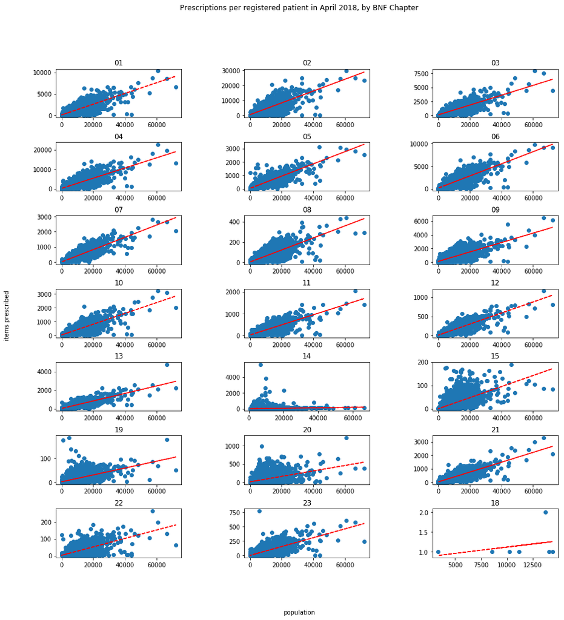

```python
#plots of presciptions by population
fig = plt.figure()
fig.set_figheight(15)
fig.set_figwidth(15)

bnfchaps = scrips_0418_grouped.BNFCHAP.unique()

for chap,num in zip(bnfchaps, range(1,22)):
    df = scrips_0418_grouped[scrips_0418_grouped['BNFCHAP']==chap]
    ax = fig.add_subplot(7,3,num)
    ax.scatter(df.NUMBER_OF_PATIENTS, df.ITEMS)
    ax.set_title(chap)
    z = np.polyfit(df.NUMBER_OF_PATIENTS, df.ITEMS, 1)
    p = np.poly1d(z)
    plt.plot(df.NUMBER_OF_PATIENTS,p(df.NUMBER_OF_PATIENTS),"r--")

fig.text(0.5,0.04, "population", ha="center", va="center")
fig.text(0.05,0.5, "items prescribed", ha="center", va="center", rotation=90)


fig.subplots_adjust(hspace=0.5,wspace=0.5)
fig.suptitle("Prescriptions per registered patient in April 2018, by BNF Chapter")
plt.show()
```

This also translates into cost, though as with quantity above there are large differences between chapters.

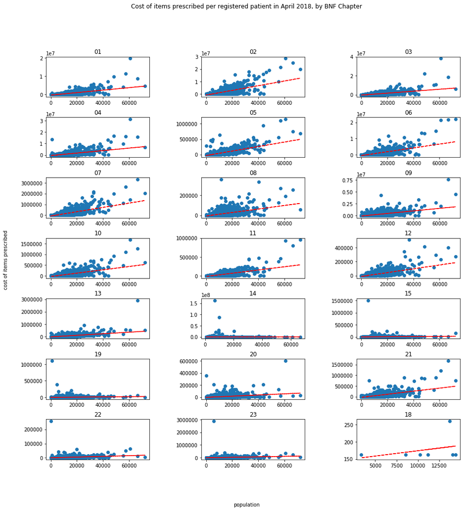

```python
fig = plt.figure()
fig.set_figheight(15)
fig.set_figwidth(15)

bnfchaps = scrips_0418_grouped.BNFCHAP.unique()

for chap,num in zip(bnfchaps, range(1,22)):
    df = scrips_0418_grouped[scrips_0418_grouped['BNFCHAP']==chap]
    ax = fig.add_subplot(7,3,num)
    ax.scatter(df.NUMBER_OF_PATIENTS, df.TOTALCOST)
    ax.set_title(chap)
    z = np.polyfit(df.NUMBER_OF_PATIENTS, df.TOTALCOST, 1)
    p = np.poly1d(z)
    plt.plot(df.NUMBER_OF_PATIENTS,p(df.NUMBER_OF_PATIENTS),"r--")

fig.text(0.5,0.04, "population", ha="center", va="center")
fig.text(0.05,0.5, "cost of items prescribed", ha="center", va="center", rotation=90)

fig.subplots_adjust(hspace=0.5,wspace=0.5)
fig.suptitle("Cost of items prescribed per registered patient in April 2018, by BNF Chapter")
plt.show()
```

```python
scrips_0418.loc[:,'COSTPP'] = scrips_0418['TOTALCOST'] / scrips_0418['NUMBER_OF_PATIENTS']
```

```python
scrips_0418_prac_grouped = scrips_0418.drop(['ACTCOST'], axis=1).groupby(['CODE', 'NUMBER_OF_PATIENTS']).sum().reset_index('NUMBER_OF_PATIENTS')
```

[figure not shown]

```python
#check axis labels
_ = plt.scatter(scrips_0418_prac_grouped.NUMBER_OF_PATIENTS,scrips_0418_prac_grouped.TOTALCOST)
_ = plt.title('Cost of prescriptions per patient at GP Practices, April 2018')
_ = plt.xlabel('Cost (excluding outliers)')
_ = plt.ylabel('Number of practices')
z = np.polyfit(scrips_0418_prac_grouped.NUMBER_OF_PATIENTS, scrips_0418_prac_grouped.TOTALCOST, 1)
p = np.poly1d(z)
plt.plot(scrips_0418_prac_grouped.NUMBER_OF_PATIENTS,p(scrips_0418_prac_grouped.NUMBER_OF_PATIENTS),"r--")
plt.show()
```

Looking overall the cost of prescriptions increases with larger practice size, although there is variation.

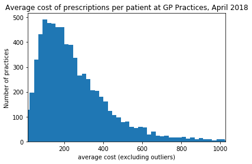

```python
min_x = scrips_0418_prac_grouped.COSTPP.quantile(.01)
max_x = scrips_0418_prac_grouped.COSTPP.quantile(.99)
_ = plt.hist(scrips_0418_prac_grouped.COSTPP, bins = 'auto')
_ = plt.xlim(min_x, max_x)
_ = plt.title('Average cost of prescriptions per patient at GP Practices, April 2018')
_ = plt.xlabel('average cost (excluding outliers)')
_ = plt.ylabel('Number of practices')
```

```python
scrips_0418_prac_grouped.COSTPP.describe()
```

```
count     7191.000000
mean       280.180256
std        800.646710
min          0.001724
25%        122.804409
50%        208.967847
75%        337.701855
max      44745.505000
Name: COSTPP, dtype: float64
```

```python
scrips_0418_prac_grouped.sort_values('COSTPP',ascending=False).head()
```

| CODE | NUMBER_OF_PATIENTS | ITEMS | QUANTITY | TOTALCOST | COSTPP |
| --- | --- | --- | --- | --- | --- |
| Y02045 | 8 | 1054 | 136990 | 3.579640e+05 | 44745.505000 |
| Y02873 | 3 | 1537 | 119971 | 9.640291e+04 | 32134.303333 |
| P82010 | 6694 | 19125 | 1000424 | 1.657064e+08 | 24754.467831 |
| A81630 | 752 | 5179 | 1314051 | 1.390687e+07 | 18493.175093 |
| Y01924 | 106 | 1714 | 2977949 | 1.712883e+06 | 16159.271415 |

For the most part practices spent less than £300 per patient on prescriptions in April 2018, although there were significant outliers which look to have special circumstances (e.g. low number of patients, serving non-typical patient groups).

### Conclusions

While larger practices prescribe more, as would be expected, there is substantial variation between practices both in terms of prescriptions per patient and what is prescribed. Where this variation is unwarranted action could be taken better target prescribing on patients who require it most and encourage the use of cheaper medications. Action could also be taken encourage the use of standard medications to reduce the variety of medications and pack sizes that are stocked; while this may increase cost in terms of prescribing more than is needed it may have savings for the supply line through stocking less variety.

## Part B: WHO Mortality

### Setup

```python
# import packages
# import numpy as np
# import matplotlib.pyplot as plt
# from scipy import stats
# import pandas as pd
```

```python
# import country data
country_codes_raw = pd.read_csv('who/country_codes.csv')
country_codes = country_codes_raw.loc[(country_codes_raw['name'] == 'Iceland') |
                                      (country_codes_raw['name'] == 'Italy') |
                                      (country_codes_raw['name'] == 'New Zealand') |
                                      (country_codes_raw['name'] == 'Australia')]
```

```python
# import pop data and filter to countries of interest
colnames = ['country', 'admin1', 'subdiv1', 'year', 'sex', 'format', 'all_age',
           '0-0', '1-1', '2-2', '3-3', '4-4', '5-9', '10-14', '15-19', '20-24',
           '25-29', '30-34', '35-39', '40-44', '45-49', '50-54', '55-59', '60-64',
           '65-69', '70-74', '75-79', '80-84', '85-89', '90-94', '95+', 'unspecified',
           'livebirths']
pop_raw = pd.read_csv('who/pop.csv', header = 0, names = colnames)
pop = pd.merge(pop_raw, country_codes, on='country', how='inner')
```

```python
# import and combine deaths data and filter to countries of interest
colnames = ['country', 'admin1', 'subdiv1', 'year', 'list', 'cause', 'sex', 'format', 'infant_format',
            'all_age', '0-0', '1-1', '2-2', '3-3', '4-4', '5-9', '10-14', '15-19',
            '20-24', '25-29', '30-34', '35-39', '40-44', '45-49', '50-54', '55-59',
            '60-64', '65-69', '70-74', '75-79', '80-84', '85-89', '90-94', '95+',
            'unspecified', 'infant_0', 'infant_1-6', 'infant_1-27', 'infant_28-364']
deaths1 = pd.read_csv('who/Morticd10_part1.csv', header = 0, names = colnames,
                      dtype = {'admin1': np.str, 'subdiv1':np.str, 'list': np.str})
deaths2 = pd.read_csv('who/Morticd10_part2.csv', header = 0, names = colnames,
                      dtype = {'admin1': np.str, 'subdiv1':np.str, 'list': np.str})
deaths_comb = deaths1.append(deaths2)
deaths = pd.merge(deaths_comb, country_codes, on='country', how='inner')
```

## Population & deaths in Iceland, Italy and New Zealand

```python
# pop and deaths in 2010 for each country then chi2
ice_pop = np.sum(pop.all_age[(pop.name == 'Iceland') & (pop.year == 2010)])
ice_dea = np.sum(deaths.all_age[(deaths.name == 'Iceland') & (deaths.year == 2010)])
ita_pop = np.sum(pop.all_age[(pop.name == 'Italy') & (pop.year == 2010)])
ita_dea = np.sum(deaths.all_age[(deaths.name == 'Italy') & (deaths.year == 2010)])
new_pop = np.sum(pop.all_age[(pop.name == 'New Zealand') & (pop.year == 2010)])
new_dea = np.sum(deaths.all_age[(deaths.name == 'New Zealand') & (deaths.year == 2010)])

print('The population of Iceland in 2010 was', ice_pop, 'while the number of deaths was', ice_dea,
      'meaning that the % of the population that died was', round(ice_dea / ice_pop * 100, 2) , '%')
print('The population of Italy in 2010 was', ita_pop, 'while the number of deaths was', ita_dea,
      'meaning that the % of the population that died was', round(ita_dea / ita_pop * 100, 2) , '%')
print('The population of New Zealand in 2010 was', new_pop, 'while the number of deaths was', new_dea,
      'meaning that the % of the population that died was', round(new_dea / new_pop * 100, 2) , '%')

chi2 = [[ice_pop, ice_dea], [ita_pop, ita_dea], [new_pop, new_dea]]
chi2, p, dof, ex = stats.chi2_contingency(chi2)
print('chi2:', round(chi2, 2), 'p:', p)
```

```
The population of Iceland in 2010 was 318041.0 while the number of deaths was 4038 meaning that the % of the population that died was 1.27 %
The population of Italy in 2010 was 60483386.0 while the number of deaths was 1169230 meaning that the % of the population that died was 1.93 %
The population of New Zealand in 2010 was 4367360.0 while the number of deaths was 57298 meaning that the % of the population that died was 1.31 %
chi2: 8851.6 p: 0.0
```

The overall rate of deaths across the three countries is significantly different but the differences are quite small.

## Distribution of deaths in Italy

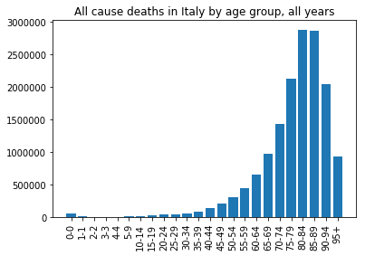

```python
# chart of all cause deaths in Italy across all years by age
cols = ['0-0', '1-1', '2-2', '3-3', '4-4', '5-9', '10-14', '15-19',
            '20-24', '25-29', '30-34', '35-39', '40-44', '45-49', '50-54', '55-59',
            '60-64', '65-69', '70-74', '75-79', '80-84', '85-89', '90-94', '95+',]

deaths_italy_sum = deaths[deaths.name == 'Italy'].groupby(['name']).sum().transpose().reset_index()
deaths_italy_pivot = deaths_italy_sum[deaths_italy_sum['index'].isin(cols)]

_ = plt.bar(deaths_italy_pivot['index'], deaths_italy_pivot['Italy'])
_ = plt.xticks(rotation=90)
_ = plt.title('All cause deaths in Italy by age group, all years')
```

## Deaths from neoplasms in Italy

```python
# total number of deaths in Italy
ita_deaths_total = deaths[deaths.name == 'Italy'].all_age.sum()
```

```python
#filter to italy neoplasms
deaths_italy_group_neop = deaths[(deaths.cause >= 'C000') & (deaths.cause <= 'D489') & (deaths.name == 'Italy')]
#group, select columns and calcaute props
deaths_italy_group_neop = deaths_italy_group_neop[['cause','all_age']].groupby(['cause']).sum().reset_index()
deaths_italy_group_neop.loc[:,'prop of neoplasm deaths'] = deaths_italy_group_neop.all_age / deaths_italy_group_neop.all_age.sum() * 100
deaths_italy_group_neop.loc[:,'prop of all deaths'] = deaths_italy_group_neop.all_age / ita_deaths_total * 100
```

```python
#most common five neoplasm causes
print('The five most common causes of deaths from neoplams (ICD-10 C00-D48) in Italy were:')
deaths_italy_group_neop5 = deaths_italy_group_neop.sort_values('prop of neoplasm deaths', ascending=False).head()
deaths_italy_group_neop5
```

```
The five most common causes of deaths from neoplams (ICD-10 C00-D48) in Italy were:
```

|  | cause | all_age | prop of neoplasm deaths | prop of all deaths |
| --- | --- | --- | --- | --- |
| 143 | C349 | 426451 | 18.964664 | 2.790770 |
| 227 | C509 | 155895 | 6.932792 | 1.020204 |
| 92 | C189 | 143188 | 6.367701 | 0.937047 |
| 76 | C169 | 125679 | 5.589059 | 0.822465 |
| 118 | C259 | 120070 | 5.339622 | 0.785759 |

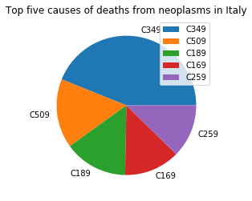

```python
# pie chart of 5 most common
_ = plt.pie(deaths_italy_group_neop5.all_age, labels=deaths_italy_group_neop5.cause)
_ = plt.legend(deaths_italy_group_neop5.cause)
_ = plt.title('Top five causes of deaths from neoplasms in Italy')
_ = plt.show()
```

The five most common causes of death from neoplasm explain a small percentage of the deaths from all causes, though around 40% of the deaths from all types of neoplasms which overall accounted for a large segment of deaths in Italy.

```python
print(round(deaths_italy_group_neop['all_age'].sum() / ita_deaths_total * 100,2), '% of all deaths were caused by neoplasms')
```

```
14.72 % of all deaths were caused by neoplasms
```

## Deaths from neosplasms in Australia during 2010 by age

```python
# Australian neoplasm deaths by age
deaths_aus_sum = deaths[(deaths.name == 'Australia') & (deaths.year == 2010) & (deaths.cause >= 'C000') & (deaths.cause <= 'D489')].groupby(['name']).sum().transpose().reset_index()
deaths_aus_pivot = deaths_aus_sum[deaths_aus_sum['index'].isin(cols)]
```

```python
# Australian population by age
pop_aus_sum = pop[(pop.name == 'Australia') & (pop.year == 2010)].groupby(['name']).sum().transpose().reset_index()
pop_aus_pivot = pop_aus_sum[pop_aus_sum['index'].isin(cols)]
```

```python
# merge deaths and pop and add prop
aus_neop = pd.merge(pop_aus_pivot, deaths_aus_pivot, on='index', suffixes=('_pop', '_deaths'))
aus_neop.loc[:,'prop'] = aus_neop.Australia_deaths / aus_neop.Australia_pop * 100
```

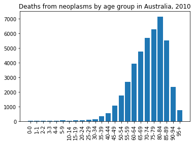

```python
# hist of number of deaths
_ = plt.bar(aus_neop['index'], aus_neop.Australia_deaths)
_ = plt.xticks(rotation=90)
_ = plt.title('Deaths from neoplasms by age group in Australia, 2010')
_ = plt.show()
```

There are substantially higher number of deaths from neoplasms in older people in Australia during 2010 though this decreases in the 85+ groups because of the smaller population as shown in the following graph

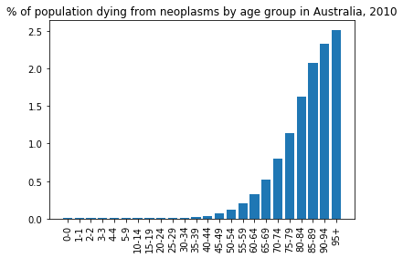

```python
# hist of prop of deaths
_ = plt.bar(aus_neop['index'], aus_neop.prop)
_ = plt.xticks(rotation=90)
_ = plt.title('% of population dying from neoplasms by age group in Australia, 2010')
_ = plt.show()
```

While the number of deaths is lower in the 85+ age groups than the 70+ age groups there are substantially higher proportions of deaths from neoplasms in older people in Australia during 2010

## Variation in deaths from neoplasms in Australia and Italy during 2010

```python
# filter to neoplasm deaths in Aus/Ita in 2010
deaths_neop = deaths[((deaths.name == 'Australia') | (deaths.name == 'Italy')) & (deaths.year == 2010) & (deaths.cause >= 'C000') & (deaths.cause <= 'D489')]

#filter columns and melt deaths
cols.append('name'), cols.append('sex'), cols.append('cause')
deaths_neop = deaths_neop[[c for c in deaths_neop.columns if c in cols]].groupby(['name', 'cause', 'sex']).sum().reset_index()
deaths_neop = pd.melt(deaths_neop, id_vars = ['name', 'sex', 'cause'], var_name = 'age_group', value_name = 'deaths')
```

```python
# filter and melt pop data
pop_ausita = pop[((pop.name == 'Australia') | (pop.name == 'Italy')) & (pop.year == 2010)]
pop_ausita = pop_ausita[[c for c in pop_ausita.columns if c in cols]].groupby(['name', 'sex']).sum().reset_index()
pop_ausita = pd.melt(pop_ausita, id_vars = ['name', 'sex'], var_name = 'age_group', value_name = 'population')
```

```python
# compare total neoplasm deaths
totals = pd.DataFrame({'pop':np.array(pop_ausita['population'].groupby(pop_ausita.name).sum()),
                     'total_deaths':np.array(deaths_neop['deaths'].groupby(deaths_neop.name).sum()),
                      'name':['Australia','Italy']})
totals.loc[:, 'prop'] = totals['total_deaths'] / totals['pop'] * 100
print(totals.set_index('name'))
chi2, p, dof, ex = stats.chi2_contingency(totals.iloc[:,0:2])
print('chi2:', chi2, 'p:', p)
```

```
                  pop  total_deaths     prop
name
Australia  22297515.0       43313.0  0.19425
Italy      60483396.0      175045.0  0.28941
chi2: 5580.16950002019 p: 0.0
```

A significantly higher proportion of the population died from neoplasms in Italy during 2010 than Australia (p<0.05) suggesting some differences in the makeup of the population, different risk factors or treatments.

##### By age

```python
# Italy neoplasm deaths by age
deaths_ita_sum = deaths[(deaths.name == 'Italy') & (deaths.year == 2010) & (deaths.cause >= 'C000') & (deaths.cause <= 'D489')].groupby(['name']).sum().transpose().reset_index()
deaths_ita_pivot = deaths_ita_sum[deaths_aus_sum['index'].isin(cols)]
# Italy population by age
pop_ita_sum = pop[(pop.name == 'Italy') & (pop.year == 2010)].groupby(['name']).sum().transpose().reset_index()
pop_ita_pivot = pop_ita_sum[pop_ita_sum['index'].isin(cols)]
ita_neop = pd.merge(pop_ita_pivot, deaths_ita_pivot, on='index', suffixes=('_pop', '_deaths'))
```

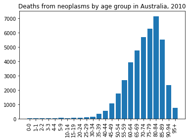

```python
# Aus hist by age
_ = plt.bar(aus_neop['index'], aus_neop.Australia_deaths)
_ = plt.xticks(rotation=90)
_ = plt.title('Deaths from neoplasms by age group in Australia, 2010')
```

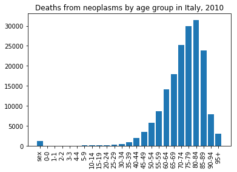

```python
# Ita hist by age
_ = plt.bar(ita_neop['index'], ita_neop.Italy_deaths)
_ = plt.xticks(rotation=90)
_ = plt.title('Deaths from neoplasms by age group in Italy, 2010')
_ = plt.show()
```

Despite the differences in the total numbers and proportions dying from neoplasms the proportion by age group is quite similar between the countries suggesting a particular age group is not accounting for the higher overall neoplasm deaths in Italy and it is spread out across age bands.

##### By sex

```python
# group by sex and merge with totals
sex = deaths_neop.loc[:, ['name', 'sex', 'deaths']].groupby(['name', 'sex']).sum().reset_index()
sex = pd.merge(sex, totals, on=['name'])
# add prop
sex.loc[:, 'prop'] = sex.deaths / sex.total_deaths * 100
sex
```

|  | name | sex | deaths | pop | total_deaths | prop |
| --- | --- | --- | --- | --- | --- | --- |
| 0 | Australia | 1 | 24557.0 | 22297515.0 | 43313.0 | 56.696604 |
| 1 | Australia | 2 | 18756.0 | 22297515.0 | 43313.0 | 43.303396 |
| 2 | Italy | 1 | 98846.0 | 60483396.0 | 175045.0 | 56.468908 |
| 3 | Italy | 2 | 76199.0 | 60483396.0 | 175045.0 | 43.531092 |

In both countries men made up a greater proportion of total neoplasm deaths again suggesting a particular sex is not accounting for the higher deaths in Italy.

##### By cause

```python
# group by cause, merge with totals, add prop
cause = deaths_neop.loc[:, ['name', 'cause', 'deaths']].groupby(['name', 'cause']).sum().reset_index()
cause = pd.merge(cause, totals, on='name', how='left')
cause.loc[:, 'prop of total deaths'] = cause.deaths / cause.total_deaths * 100
cause = cause.drop('prop', axis = 1)
```

```python
# top 5 for Aus
cause.loc[cause['name'] == 'Australia'].sort_values('prop of total deaths', ascending=False).head()
```

|  | name | cause | deaths | pop | total_deaths | prop of total deaths |
| --- | --- | --- | --- | --- | --- | --- |
| 93 | Australia | C349 | 7989.0 | 22297515.0 | 43313.0 | 18.444809 |
| 163 | Australia | C61 | 3236.0 | 22297515.0 | 43313.0 | 7.471198 |
| 148 | Australia | C509 | 2865.0 | 22297515.0 | 43313.0 | 6.614642 |
| 216 | Australia | C809 | 2783.0 | 22297515.0 | 43313.0 | 6.425323 |
| 72 | Australia | C259 | 2367.0 | 22297515.0 | 43313.0 | 5.464872 |

```python
# top 5 for Ita
cause.loc[cause['name'] == 'Italy'].sort_values('prop of total deaths', ascending=False).head()
```

|  | name | cause | deaths | pop | total_deaths | prop of total deaths |
| --- | --- | --- | --- | --- | --- | --- |
| 457 | Italy | C349 | 33416.0 | 60483396.0 | 175045.0 | 19.089948 |
| 520 | Italy | C509 | 12231.0 | 60483396.0 | 175045.0 | 6.987346 |
| 408 | Italy | C189 | 11638.0 | 60483396.0 | 175045.0 | 6.648576 |
| 432 | Italy | C259 | 9683.0 | 60483396.0 | 175045.0 | 5.531720 |
| 393 | Italy | C169 | 9523.0 | 60483396.0 | 175045.0 | 5.440315 |